# Ordinary Differential Equations

Yuji Saikai ysaikai@unimelb.edu.au School of Mathematics and Statistics The University of Melbourne

These notes are based on Chapter 13 of Jones, O., Maillardet, R., & Robinson, A. (2014). *Introduction to scientific programming and simulation using R* (2nd ed.). CRC Press.

# Introduction

Recall, from your calculus class, that solving a system of ordinary differential equations (ODEs)
$$\frac{d}{dt}\mathbf{y}(t) = \mathbf{f}(\mathbf{y}(t))$$
means finding a (vector-valued) function $\mathbf{y}(t)$ that satisfies the system of equations. The following is a famous model based on the [Lotka-Volterra equations](https://en.wikipedia.org/wiki/Lotka–Volterra_equations).

> In differential equations, notations can easily get confusing. In these notes, I explicitly use boldface to denote vectors and vector-valued functions (e.g., $\mathbf{y}$ and $\mathbf{f}$).

> In these notes, we consider only autonomous systems, that is, the right-hand side depends on $t$ only through $\mathbf{y}(t)$.

## Predator–prey model

The predator-prey model is used to describe the population dynamics of two species, one as a predator and the other as a prey. The model consists of a pair of ODEs:
$$\begin{align}
\frac{dy_1}{dt} &= ay_1 - by_1y_2\\
\frac{dy_2}{dt} &= gby_1y_2 - ey_2
\end{align}$$
where

- $y_1$ : prey population
- $y_2$ : predator population
- $a$ : natural growth rate of prey in the absence of predation
- $b$ : death rate due to the predation
- $g$ : birth rate of predator due to the captured prey
- $e$ : natural death rate of predator.

The system is known to have periodic solutions, which do not allow simple expressions. Fortunately, it is still easy to obtain an implicit equation of $y_1$ and $y_2$.

Eliminating $dt$ from the above system of ODEs, we have:
$$\begin{alignat}{2}
&&(ay_1-by_1y_2)dy_2 &= (gby_1y_2-ey_2)dy_1\\
&\Leftrightarrow\quad &\int \frac{a-by_2}{y_2}dy_2 &= \int \frac{gby_1-e}{y_1}dy_1\\
&\Leftrightarrow\quad & C &= gby_1-e\log(y_1)+by_2-a\log(y_2)
\end{alignat}$$
where $C$ is a constant.

With $a=0.05$, $b=0.0002$, $g=0.8$, $e=0.03$, and $C=-0.3$, we have the following orbit in a phase space.

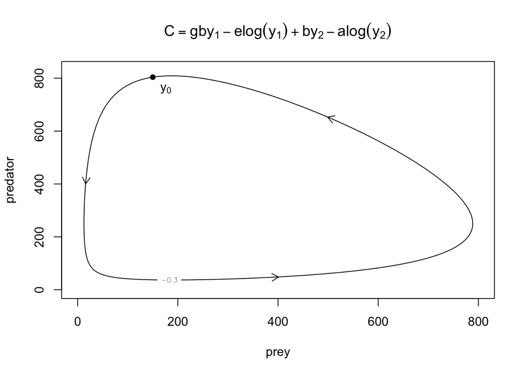

```r
a <- 0.05
b <- 0.0002
g <- 0.8
e <- 0.03
C <- -0.3
y1 <- seq(0, 800, length=1000)
y2 <- seq(0, 830, length=1000)
out <- outer(y1, y2, function(y1,y2) g*b*y1 - e*log(y1) + b*y2 - a*log(y2) )
contour(y1, y2, out, levels=C, xlab="prey", ylab="predator")
from_x <- c(16.05, 400, 500)
from_y <- c(401, 48, 652.3)
to_x <- c(16, 401, 499)
to_y <- c(400, 48.1, 653)
y0 <- c(150, 804)
points(y0[1], y0[2],pch=16)
text(y0[1], y0[2]-50, expression(y[0]), pos=4)
arrows(from_x, from_y, to_x, to_y, length=.1)
title(expression(C == g*b*y[1] - e*log(y[1]) + b*y[2] - a*log(y[2])))
```

Just as we can find closed-form antiderivatives only in special integration problems, we can find analytical solutions only for some types of ODEs. Again, numerical methods allow us to (approximately) solve a wider class of problems.

## Numerical solutions

As nonsensical as it sounds, if we knew $\mathbf{y}(t)$ on the right-hand side of the above ODEs, a solution would be a usual integral with respect to $t$:
$$\mathbf{y}(t) = \int \mathbf{f}(\mathbf{y}(t))dt .$$
But, of course, we do not know $\mathbf{y}(t)$, which is the point of this exercise.

Nevertheless, when we work on an initial value problem:
$$\mathbf{y}(h) = \mathbf{y}(0) + \int_0^h \mathbf{f}(\mathbf{y}(t))dt ,$$
such a “nonsensical” integral gives us a reminder that **solving a differential equation is doing integration.**

Almost always, whether it is analytical or numerical integration, **when it is hard, we approximate the integrand by a simple function**.

> In analytical integration, an integral is defined as a limit. So, it does not matter whether we approximate the integrand by a function or constant values. In numerical integration, on the other hand, the choice of simple functions affects the performance of approximation because we always have to settle for finite granularity depending on our computational capacity.

Recall the technique used in Numerical Integration, where we approximate a complex function over each subinterval by simple functions so that we can carry out an integral with ease. Specifically, linear functions in the trapezoidal rule and quadratic functions in Simpson’s rule. Why not applying the same idea here — approximating an unknown function $\mathbf{y}(t)$?

> Besides the similarity, also note the difference. In the standard numerical integration, we can evaluate the function wherever we like. In contrast, here, we can evaluate only the derivative $\frac{d\mathbf{y}}{dt} = \mathbf{f}$ and evaluation points $\{\mathbf{y}(t)\}$ themselves depend on our repeated approximation.

# Euler’s method

Let’s try linear approximation. Let $\hat{\mathbf{y}}(t)$ be approximation to $\mathbf{y}(t)$ for $t>0$, and $\hat{\mathbf{y}}(0) = \mathbf{y}(0)$. If $\mathbf{y}(t)$ is linear, $\mathbf{f}(\mathbf{y}(t)) = \frac{d}{dt}\mathbf{y}(t)$ is constant. A natural choice is $\mathbf{f}(\mathbf{y}(t)) = \mathbf{f}(\mathbf{y}(0))$ for $t\in[0,h]$, and we can easily compute $\mathbf{f}(\mathbf{y}(0))$ using the knowledge of $\mathbf{y}(0)$ and $\mathbf{f}$. Thus,
$$\begin{align}
\hat{\mathbf{y}}(h) &= \hat{\mathbf{y}}(0) + \int_0^h \mathbf{f}(\hat{\mathbf{y}}(0))dt\\
&= \hat{\mathbf{y}}(0) + h\mathbf{f}(\hat{\mathbf{y}}(0))
\end{align}$$

If we are happy to make repeated approximation, then we have Euler’s method for solving ODEs:
$$\begin{align}
\hat{\mathbf{y}}(nh+h) &= \hat{\mathbf{y}}(nh) + \int_{nh}^{nh+h} \mathbf{f}(\hat{\mathbf{y}}(nh))dt\\
&= \hat{\mathbf{y}}(nh) + h\mathbf{f}(\hat{\mathbf{y}}(nh))
\end{align}$$
for $n\in\{0,1,\dots\}$.

Approximation errors $\|\hat{\mathbf{y}}(nh) - \mathbf{y}(nh)\|$ are accumulated over time.

Let’s illustrate it using the predator–prey model. Each process starts at $\mathbf{y}_0=(150, 804)$, which is a point on the orbit.

```r
LV <- function(y) c(a*y[1] - b*y[1]*y[2], g*b*y[1]*y[2] - e*y[2])
```

```r
euler <- function(f, t0, y0, h, N) {
  Y <- matrix(nrow=N+1, ncol=length(y0)) # empty matrix
  Y[1,] <- y0 # R has 1-base indexing. Y[1,] for y0.
  t <- t0
  for (n in 1:N) {
    Y[n+1,] <- Y[n,] + h*f(Y[n,])
    t <- t + h
  }
  return(Y) # returned value is a matrix
}
```

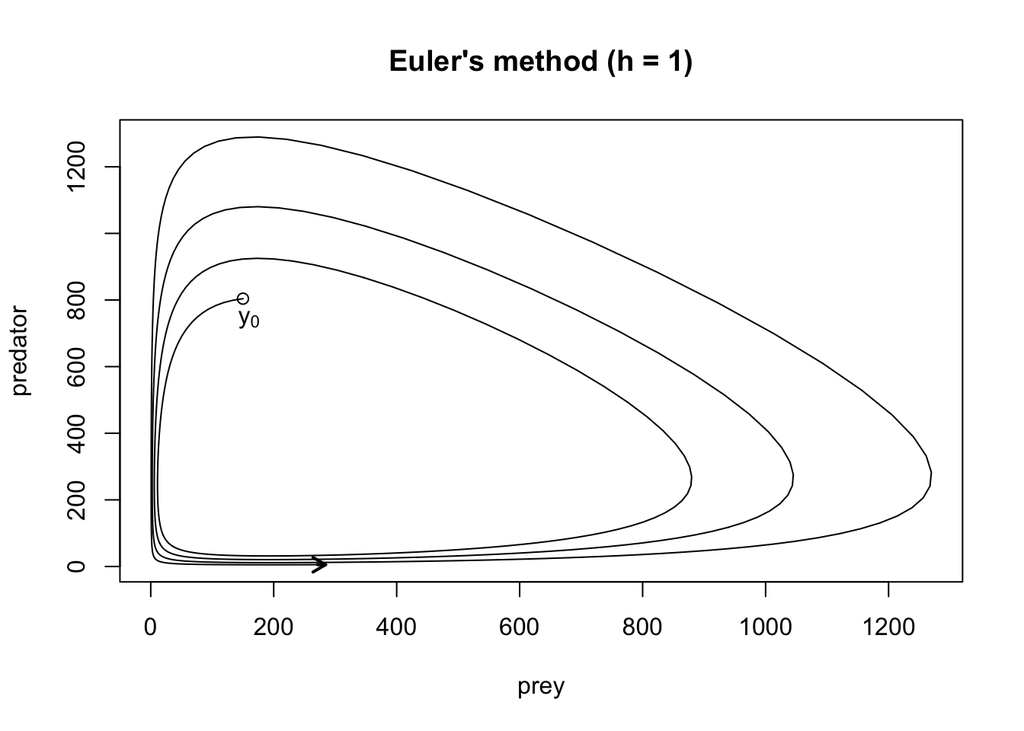

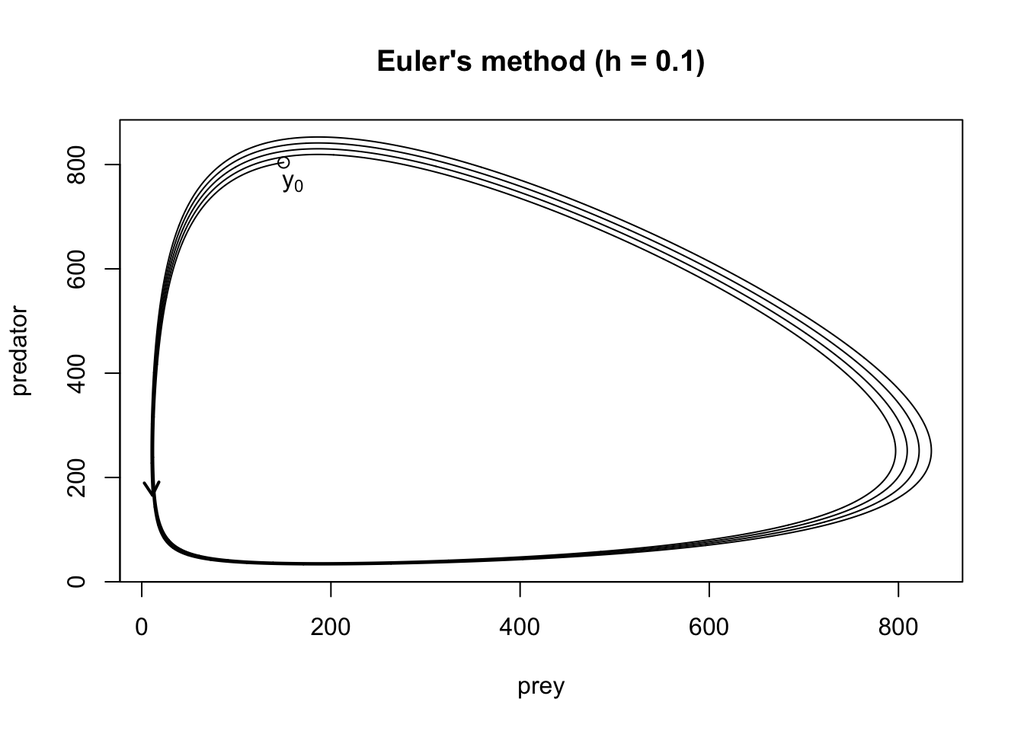

```r
for (h in c(1, 0.1)) {
  N <- 880/h
  Y <- euler(LV, 0, y0, h, N)
  plot(Y[,1], Y[,2], type='l', xlab="prey", ylab="predator")
  points(Y[1,1], Y[1,2])
  text(Y[1,1]+10, Y[1,2], expression(y[0]), pos=1)
  arrows(Y[N+1,1], Y[N+1,2],
         Y[N+1,1]+LV(Y[N+1,])[1], Y[N+1,2]+LV(Y[N+1,])[2],
         length=.1, lwd=2)
  title(paste("Euler's method (h = ", h, ")", sep=""))
}
```

While finer approximation with smaller $h$ certainly produces smaller errors, even with $h=0.1$, there is noticeable outward divergence from the orbit. Hence, our task is to reduce errors through better approximation of $\mathbf{y}(t)$.

Remember that, when approximating $\mathbf{y}(t)$, we make two decisions: linearity and its slope. Let’s keep the linearity because it allows us to eliminate the dependency of the integrand $\mathbf{f}$ on $t$, thereby making the integral trivial. So, **we try to devise better slopes** than the naïve choice $\mathbf{f}(\hat{\mathbf{y}}(nh))$.

> In calculus, $\mathbf{f}$ is often called a **vector field**, a vector-valued function that points out a direction in which $\mathbf{y}$ is moving from $\mathbf{y}(t)$ at $t$. Such a direction is called a “slope” in these notes.

# Midpoint method

The midpoint method (a.k.a. the second-order Runge–Kutta) provides an intuitive approach to a better slope. The idea is simple: if $\mathbf{y}(t)$ is a smooth function of $t$ over $t\in[nh, nh+h]$, then we expect the slope at the midpoint $t=nh+h/2$ is better than the slope at $t=nh$. The below figure may help you visualize it.

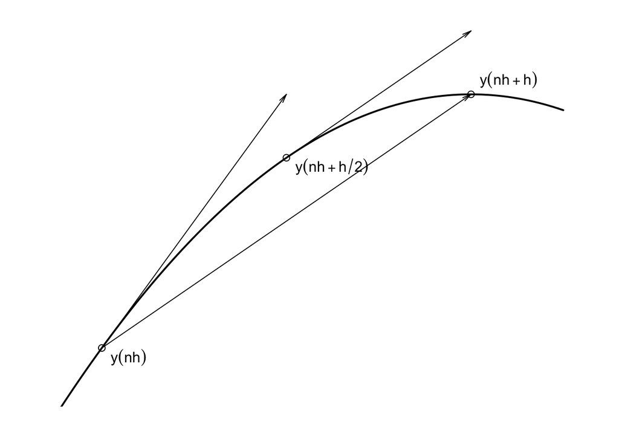

```r
par(mar=c(2,2,0,2))
curve(-x^2, from=-.9, to=.2, ylim=c(-.75,.2), lwd=2,
      axes=FALSE, ann=FALSE, xaxt="n", yaxt="n")
x <- c(-.8,-.4,0)
y <- c(-.64,-.16,0)
points(x, y)
arrows(x[1],y[1],-.4,0,length=.1,angle=12)
text(x[1],y[1]-.03,expression(y(nh)),pos=4)
arrows(x[2],y[2],0,y[2]+.32,length=.1,angle=12)
text(x[2],y[2]-.03,expression(y(nh+h/2)),pos=4)
arrows(x[1],y[1],x[3],y[3],length=.1,angle=12)
text(x[3],y[3]+.03,expression(y(nh+h)),pos=4)
```

If we buy the idea of using $\mathbf{f}(\hat{\mathbf{y}}(nh+h/2))$ as a better slope, then we need $\hat{\mathbf{y}}(nh+h/2)$, which we do not know. At this point, we give up and go back to Euler’s method, i.e.,
$$\hat{\mathbf{y}}(nh+h/2) = \hat{\mathbf{y}}(nh) + \frac{h}{2}\mathbf{f}(\hat{\mathbf{y}}(nh)) .$$
Let’s review the idea of midpoint method.

1. Euler’s method can be improved by the midpoint method, which…
2. Computes $\hat{\mathbf{y}}(nh+h)$ using $\mathbf{f}(\hat{\mathbf{y}}(nh+h/2))$, which…
3. Requires $\hat{\mathbf{y}}(nh+h/2)$, which is…
4. Computed by Euler’s method.

Here is the idea in action.

```r
midpoint <- function(f, t0, y0, h, N) {
  Y <- matrix(0, nrow=N+1, ncol=length(y0))
  Y[1,] <- y0
  t <- t0
  for (n in 1:N) {
    y.m <- Y[n,] + h/2*f(Y[n,]) # Euler for the midpoint
    Y[n+1,] <- Y[n,] + h*f(y.m)
    t <- t + h
  }
  return(Y)
}
```

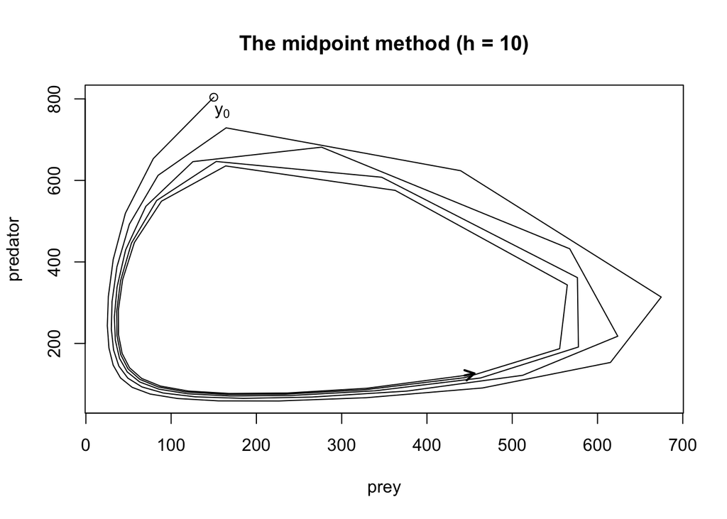

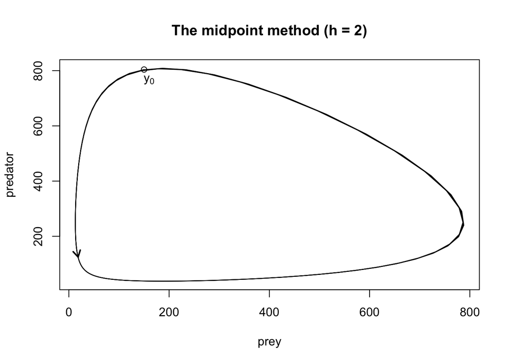

```r
for (h in c(10, 2)) {
  N <- 880/h
  Y <- midpoint(LV, 0, y0, h, N)
  plot(Y[,1], Y[,2], type='l', xlab="prey", ylab="predator")
  points(Y[1,1], Y[1,2])
  text(Y[1,1]+10, Y[1,2], expression(y[0]), pos=1)
  arrows(Y[N+1,1], Y[N+1,2],
         Y[N+1,1]+LV(Y[N+1,])[1], Y[N+1,2]+LV(Y[N+1,])[2],
         length=.1, lwd=2)
  title(paste("The midpoint method (h = ",h,")", sep=""))
}
```

The result is dramatic improvement. Even $h=2$ is clearly better than Euler’s method with $h=0.1$.

# Fourth-order Runge–Kutta

We can push the idea further; the slope used in linear approximation is a weighted average of the following four slope estimates:
$$\begin{align}
\mathbf{k}_1 &= \mathbf{f}(\hat{\mathbf{y}}(nh))\\
\mathbf{k}_2 &= \mathbf{f}(\hat{\mathbf{y}}(nh)+\tfrac{h}{2}\mathbf{k}_1)\\
\mathbf{k}_3 &= \mathbf{f}(\hat{\mathbf{y}}(nh)+\tfrac{h}{2}\mathbf{k}_2)\\
\mathbf{k}_4 &= \mathbf{f}(\hat{\mathbf{y}}(nh)+h\mathbf{k}_3)
\end{align}$$

> $\mathbf{k}_2$ is the one used in the midpoint method.

The fourth-order Runge–Kutta (RK4) computes $\hat{\mathbf{y}}(nh+h)$ as follows:
$$\hat{\mathbf{y}}(nh+h) = \hat{\mathbf{y}}(nh) + h\left( \frac{1}{6}\mathbf{k}_1 + \frac{1}{3}\mathbf{k}_2 + \frac{1}{3}\mathbf{k}_3 + \frac{1}{6}\mathbf{k}_4 \right) .$$

Here is the idea in action.

```r
RK4 <- function(f, t0, y0, h, N) {
  Y <- matrix(0, nrow=N+1, ncol=length(y0))
  Y[1,] <- y0
  t <- t0
  for (n in 1:N) {
    k1 <- f(Y[n,])
    k2 <- f(Y[n,] + h/2*k1)
    k3 <- f(Y[n,] + h/2*k2)
    k4 <- f(Y[n,] + h*k3)
    Y[n+1,] <- Y[n,] + h*(k1/6 + k2/3 + k3/3 + k4/6)
    t <- t + h
  }
  return(Y)
}
```

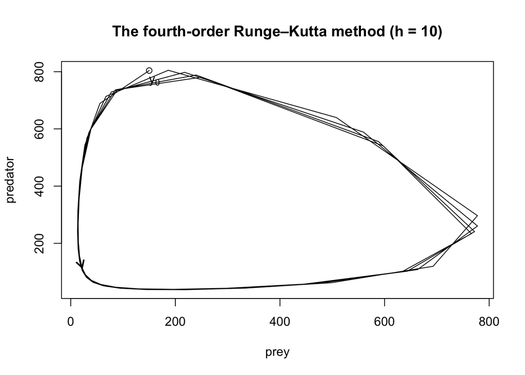

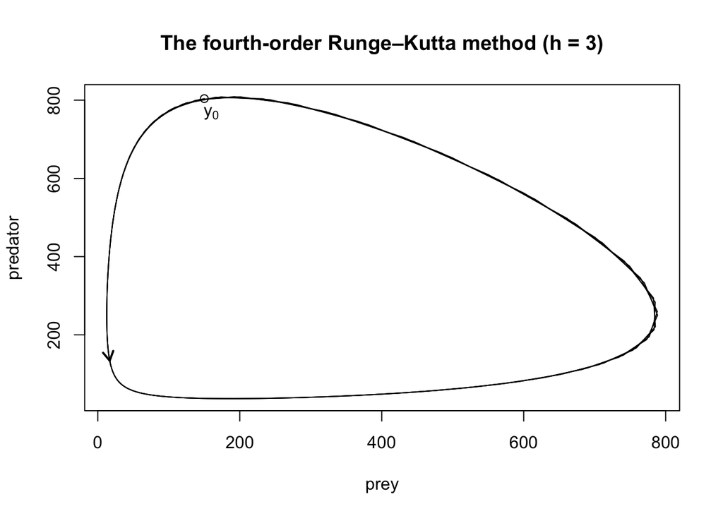

```r
for (h in c(10, 3)) {
  N <- 880/h
  Y <- RK4(LV, 0, y0, h, N)
  plot(Y[,1], Y[,2], type='l', xlab="prey", ylab="predator")
  points(Y[1,1], Y[1,2])
  text(Y[1,1]+10, Y[1,2], expression(y[0]), pos=1)
  arrows(Y[N+1,1], Y[N+1,2],
         Y[N+1,1]+LV(Y[N+1,])[1], Y[N+1,2]+LV(Y[N+1,])[2],
         length=.1, lwd=2)
  title(paste("The fourth-order Runge–Kutta method (h = ",h,")", sep=""))
}
```

The result is further improvement. RK4 with $h=3$ looks just like the midpoint method with $h=2$.

# Computational efficiency

The midpoint and RK4 improve the accuracy of linear approximation through additional computation (i.e., more calls of $f$ to get better slopes).

*Does the improved accuracy justify the additional computation, or should we just use the Euler scheme and reduce $h$?*

Specifically, here is the trade-off:

| Method | Error per step | $f$ calls per step |
| --- | --- | --- |
| Euler | $O(h^2)$ | 1 |
| Midpoint | $O(h^3)$ | 2 |
| RK4 | $O(h^5)$ | 4 |

It is hard to give a definite answer based only on this information because many factors affect the answer. For example:

- While $f$ calls are given by specific numbers, $O(n)$ is by definition silent on scalar multiples.
- Cumulative errors depend on how many steps we run.
- Available computational resource is a key determinant.

To get a feel, let’s conduct a simple numerical experiment.

An ODE to solve is $\frac{dy}{dt} = -y$ with $y(0)=1$, to which we know the analytical solution $y(t)=e^{-t}$. We examine how many $f$ calls are required to achieve $|\hat{y}(1)-y(1)|\leq\epsilon$ by repeatedly reducing $h$ by half. We test six tolerance values: $\epsilon\in\{10^{-1}, 10^{-2}, 10^{-3}, 10^{-4}, 10^{-5}, 10^{-6}\}$.

```r
# parameters
methods <- list(euler, midpoint, RK4)
f <- function(y) -y # RHS of the ODE
y1.true <- exp(-1) # y(t=1)
epsilons <- 10^(-(1:6))

re <- matrix(nrow=3, ncol=length(epsilons)) # for results

y.N <- function(Y) Y[length(Y)] # pick up the last row of the matrix Y
run <- function(j, col, epsilon) {
  h <- 1
  method <- methods[[j]]
  y <- y.N(method(f, t0=0, y0=1, h=h, N=1/h))
  while (abs(y - y1.true) > epsilon) {
    h <- h/2
    y <- y.N(method(f, t0=0, y0=1, h=h, N=1/h))
  }
  # 1, 2, and 4 evaluations per step in method 1, 2, and 3 respectively.
  return(2^(j-1)/h)
}

for (col in 1:length(epsilons)) {
  epsilon <- epsilons[col]

  for (i in 1:3) {
    re[i,col] <- run(i, col, epsilon)
  }
}
```

The result is summarised below.

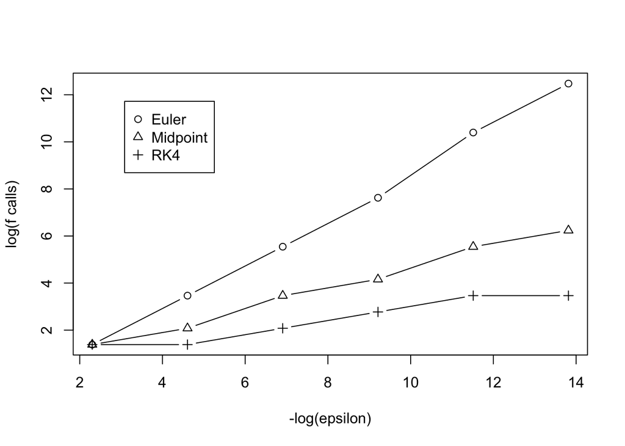

| $\epsilon$ | $10^{-1}$ | $10^{-2}$ | $10^{-3}$ | $10^{-4}$ | $10^{-5}$ | $10^{-6}$ |
| --- | --- | --- | --- | --- | --- | --- |
| Euler | 4 | 32 | 256 | 2048 | 32768 | 262144 |
| Midpoint | 4 | 8 | 32 | 64 | 256 | 512 |
| RK4 | 4 | 4 | 8 | 16 | 32 | 32 |

```r
plot(-log(epsilons), log(re[1,]), type='b',
     pch=1, xlab = '-log(epsilon)', ylab = 'log(f calls)')
lines(-log(epsilons), log(re[2,]), type='b', pch=2)
lines(-log(epsilons), log(re[3,]), type='b', pch=3)
legend('topleft', legend = c('Euler', 'Midpoint', 'RK4'),
       pch = c(1, 2, 3), inset = .1)
```

In this experiment, as expected, RK4 performs uniformly better than the others.